# Purity and immune adjustment of module enrichment

Junkai Wang

09/22/2026

ESTIMATE stromal/immune scores for the three cohorts and CPE tumor purity for TCGA, then differential expression and module enrichment re-run with purity and immune score as covariates. Callari has no validated purity estimate, so its ESTIMATE score is used as the purity proxy.

## 1. Paths

```r
tcga_dir <- "~/Desktop/MBC/01_TCGA_BRCA_Data_Cleanup/Output"
gtex_dir <- "~/Desktop/MBC/02_GTEX_Breast_Data_Cleanup_V8/Output"
call_dir <- "~/Desktop/MBC/03_Callari_Data_Cleanup/processed"
net_dir  <- "~/Desktop/MBC/06_Network_analysis"
out_dir  <- "~/Desktop/MBC/07_Cell_Type_Deconvolution/Output"
dir.create(out_dir, recursive = TRUE, showWarnings = FALSE)
```

## 2. Build the three expression matrices

```r
tcga_cnt  <- fread(file.path(tcga_dir, "output_TCGA_BRCA_ERpos_counts.tsv"))
tcga_clin <- fread(file.path(tcga_dir, "output_TCGA_BRCA_ERpos_clinical.tsv"))

tcga_male   <- tcga_clin[gender == "male",   patient_id]
tcga_female <- tcga_clin[gender == "female", patient_id]
cat("TCGA ER+:", length(tcga_male), "male /", length(tcga_female), "female\n")
```

```
## TCGA ER+: 12 male / 795 female
```

```r
cnt <- as.matrix(tcga_cnt[, -1])
rownames(cnt) <- tcga_cnt$GeneSymbol

group <- factor(ifelse(colnames(cnt) %in% tcga_male, "male", "female"))
x <- DGEList(cnt, group = group)
keep <- filterByExpr(x)
x <- x[keep, , keep.lib.sizes = FALSE]
cat("genes after filterByExpr:", sum(keep), "of", length(keep), "\n")
```

```
## genes after filterByExpr: 31089 of 59427
```

```r
x <- calcNormFactors(x, method = "TMM")
tcga_expr <- cpm(x, log = TRUE)

tcga_meta <- align_meta(tcga_clin[, .(sample = patient_id, sex = gender)], tcga_expr)
cat("TCGA:", sum(tcga_meta$sex == "male"), "male /",
    sum(tcga_meta$sex == "female"), "female |", nrow(tcga_expr), "genes\n")
```

```
## TCGA: 12 male / 795 female | 31089 genes
```

```r
ce <- fread(file.path(call_dir, "output_Callari_expr_symbol.txt"))
call_expr <- as.matrix(ce[, -1]); rownames(call_expr) <- ce[[1]]

call_meta <- fread(file.path(call_dir, "output_Callari_metadata.txt"))[, .(sample, sex)]
call_meta <- align_meta(call_meta, call_expr)
cat("Callari:", sum(call_meta$sex == "male"), "male /",
    sum(call_meta$sex == "female"), "female |", nrow(call_expr), "genes\n")
```

```
## Callari: 37 male / 53 female | 7792 genes
```

```r
gtex_m <- fread(file.path(gtex_dir, "output_GTEx_RNA_male_breast.txt"))
gtex_f <- fread(file.path(gtex_dir, "output_GTEx_RNA_female_breast.txt"))
setnames(gtex_m, 1, "gene_id"); setnames(gtex_f, 1, "gene_id")
stopifnot(identical(gtex_m$gene_id, gtex_f$gene_id))

gtex_male   <- setdiff(names(gtex_m), c("gene_id", "Description"))
gtex_female <- setdiff(names(gtex_f), c("gene_id", "Description"))

gtex <- cbind(gtex_m, gtex_f[, ..gtex_female])
gtex <- gtex[!duplicated(Description)]
cnt  <- as.matrix(gtex[, c(gtex_male, gtex_female), with = FALSE])
rownames(cnt) <- gtex$Description

x <- DGEList(cnt, group = rep(c("male", "female"),
                              c(length(gtex_male), length(gtex_female))))
x <- x[filterByExpr(x), , keep.lib.sizes = FALSE]
gtex_expr <- cpm(calcNormFactors(x, method = "TMM"), log = TRUE)

gtex_meta <- data.table(sample = colnames(gtex_expr),
                        sex = rep(c("male", "female"),
                                  c(length(gtex_male), length(gtex_female))))
cat("GTEx:", length(gtex_male), "male /", length(gtex_female),
    "female |", nrow(gtex_expr), "genes\n")
```

```
## GTEx: 291 male / 168 female | 22827 genes
```

## 3. ESTIMATE

All three cohorts use `platform = "illumina"`, which returns the stromal, immune and combined scores only. ESTIMATE’s TumorPurity formula (`"affymetrix"`) was fitted on Affymetrix intensities and is not valid for the Callari two-color log2 ratios, so no ESTIMATE purity is used. The scores are rank-based (ssGSEA) and are compared between sexes within each cohort, not across cohorts.

```r
run_estimate <- function(expr) {
  merged <- filterCommonGenes(expr, id = "GeneSymbol")
  sc <- as.data.frame(estimateScore(merged, platform = "illumina"))
  out <- as.data.table(t(sc))
  stopifnot(nrow(out) == ncol(expr), !anyNA(out))
  out[, sample := colnames(expr)]
  setcolorder(out, "sample")[]
}

est_tcga <- run_estimate(tcga_expr)
```

```
## [1] "Merged dataset includes 9595 genes (817 mismatched)."
## [1] "1 gene set: StromalSignature  overlap= 135"
## [1] "2 gene set: ImmuneSignature  overlap= 139"
```

```r
est_call <- run_estimate(call_expr)
```

```
## [1] "Merged dataset includes 5308 genes (5104 mismatched)."
## [1] "1 gene set: StromalSignature  overlap= 85"
## [1] "2 gene set: ImmuneSignature  overlap= 86"
```

```r
est_gtex <- run_estimate(gtex_expr)
```

```
## [1] "Merged dataset includes 9329 genes (1083 mismatched)."
## [1] "1 gene set: StromalSignature  overlap= 137"
## [1] "2 gene set: ImmuneSignature  overlap= 140"
```

```r
head(est_tcga)
```

```
##          sample StromalScore ImmuneScore ESTIMATEScore
##          <char>        <num>       <num>         <num>
## 1: TCGA-A8-A09E   -310.78274   -766.2597    -1077.0424
## 2: TCGA-A7-A0DC   -862.68477  -1358.0196    -2220.7044
## 3: TCGA-A8-A08F    716.22483    767.5866     1483.8115
## 4: TCGA-A8-A091     95.26761   -475.1480     -379.8804
## 5: TCGA-AO-A0JI   -622.31709   -679.8707    -1302.1878
## 6: TCGA-A2-A0D4   -493.04717  -1008.6204    -1501.6676
```

```r
head(est_call)
```

```
##    sample StromalScore ImmuneScore ESTIMATEScore
##    <char>        <num>       <num>         <num>
## 1:   Bm01     1475.401    401.8355      1877.237
## 2:   Bm03     1422.143    481.2812      1903.424
## 3:   Bm06     1669.477    809.2887      2478.766
## 4:   Bm07     1538.660    731.0522      2269.713
## 5:   Bm08     1170.808    942.0145      2112.823
## 6:   Bm10     1441.714   1113.7959      2555.510
```

```r
head(est_gtex)
```

```
##                      sample StromalScore ImmuneScore ESTIMATEScore
##                      <char>        <num>       <num>         <num>
## 1: GTEX-111YS-1926-SM-5GICC     137.5945   -838.9623    -701.36773
## 2: GTEX-117XS-1926-SM-5GICO     961.6145    273.2028    1234.81727
## 3: GTEX-117YX-1426-SM-5H12H    1041.6162    202.4341    1244.05030
## 4: GTEX-1192X-2326-SM-5987X     256.1896   -349.9750     -93.78542
## 5: GTEX-11DXW-0626-SM-5N9ER     680.7527   -585.0132      95.73948
## 6: GTEX-11DXY-2326-SM-5GICW    1027.9961   -162.2677     865.72836
```

```r
tcga_meta <- align_meta(merge(tcga_meta, est_tcga, by = "sample"), tcga_expr)
call_meta <- align_meta(merge(call_meta, est_call, by = "sample"), call_expr)
gtex_meta <- align_meta(merge(gtex_meta, est_gtex, by = "sample"), gtex_expr)
```

## 4. Tumor purity for TCGA (CPE)

`Tumor.purity` in TCGAbiolinks is the Aran et al. 2015 pan-cancer table (ABSOLUTE, ESTIMATE, LUMP, IHC and the CPE consensus). CPE is used for all samples so that one method applies throughout; ABSOLUTE is kept for reference. Matching is at patient level. Purity is available for TCGA only.

```r
library(TCGAbiolinks)
data(Tumor.purity)
pur <- as.data.table(Tumor.purity)
pur[, `:=`(patient  = substr(Sample.ID, 1, 12),
           ABSOLUTE = as.numeric(gsub(",", ".", ABSOLUTE)),
           CPE      = as.numeric(gsub(",", ".", CPE)))]
pur <- unique(pur[, .(patient, ABSOLUTE, CPE)], by = "patient")

tcga_meta[, patient := substr(sample, 1, 12)]
tcga_meta <- merge(tcga_meta, pur, by = "patient", all.x = TRUE)
tcga_meta[, purity := CPE]
tcga_meta <- align_meta(tcga_meta, tcga_expr)

tcga_meta[, .(n = .N,
              CPE_available      = sum(!is.na(CPE)),
              ABSOLUTE_available = sum(!is.na(ABSOLUTE)),
              missing            = sum(is.na(purity))), by = sex]
```

```
##       sex     n CPE_available ABSOLUTE_available missing
##    <char> <int>         <int>              <int>   <int>
## 1: female   795           787                602       8
## 2:   male    12            12                  9       0
```

If male cases are lost to missing purity, that count must be reported — with n = 12 it materially affects any downstream adjustment.

## 5. Purity and immune scores by sex

```r
vars_all <- c("StromalScore", "ImmuneScore", "ESTIMATEScore", "purity")

by_sex <- rbindlist(lapply(
  list(TCGA = tcga_meta, Callari = call_meta, GTEx = gtex_meta),
  function(d) {
    vars <- intersect(vars_all, names(d))
    rbindlist(lapply(vars, function(v) {
      x <- d[sex == "male", get(v)]; y <- d[sex == "female", get(v)]
      data.table(variable = v,
                 male_median   = median(x, na.rm = TRUE),
                 female_median = median(y, na.rm = TRUE),
                 pvalue = wilcox.test(x, y)$p.value)
    }))
  }), idcol = "cohort")

by_sex[, FDR := p.adjust(pvalue, "BH")][]
```

```
##      cohort      variable male_median female_median       pvalue          FDR
##      <char>        <char>       <num>         <num>        <num>        <num>
##  1:    TCGA  StromalScore   168.21395     478.19509 2.193110e-01 0.3130697565
##  2:    TCGA   ImmuneScore  -406.29905     -92.56757 2.997829e-02 0.0999276466
##  3:    TCGA ESTIMATEScore  -242.19603     385.22397 5.258608e-02 0.1099999718
##  4:    TCGA        purity     0.78795       0.75460 2.671337e-01 0.3130697565
##  5: Callari  StromalScore  1324.78595    1421.86405 4.654947e-01 0.4654946947
##  6: Callari   ImmuneScore   806.33044     899.87360 5.499999e-02 0.1099999718
##  7: Callari ESTIMATEScore  2156.92494    2358.14074 9.762751e-02 0.1627125092
##  8:    GTEx  StromalScore   696.60036     543.87109 9.778019e-05 0.0009778019
##  9:    GTEx   ImmuneScore  -321.71775    -354.99585 2.817628e-01 0.3130697565
## 10:    GTEx ESTIMATEScore   441.20244     180.48138 4.704403e-03 0.0235220156
```

## Figure: purity and immune scores by sex

Each score is shown by sex in every cohort, annotated with the FDR from the test above. Tumor purity (CPE) is shown for TCGA only.

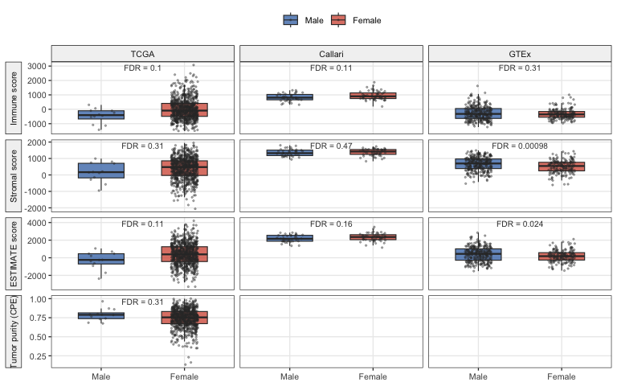

```r
var_lv  <- c("ImmuneScore", "StromalScore", "ESTIMATEScore", "purity")
var_lab <- c("Immune score", "Stromal score", "ESTIMATE score", "Tumor purity (CPE)")

## long format: one row per sample x variable, across all three cohorts
sc_long <- rbindlist(lapply(
  list(TCGA = tcga_meta, Callari = call_meta, GTEx = gtex_meta),
  function(d) {
    vars <- intersect(vars_all, names(d))
    melt(d[, c("sample", "sex", vars), with = FALSE],
         id.vars = c("sample", "sex"),
         variable.name = "variable", value.name = "score")
  }), idcol = "cohort")

sc_long[, cohort := factor(cohort, c("TCGA", "Callari", "GTEx"))]
sc_long[, sex := factor(sex, c("male", "female"))]
sc_long[, variable := factor(variable, var_lv, var_lab)]
sc_long <- sc_long[!is.na(score)]

## FDR labels from section 5
lab <- copy(by_sex)
lab[, cohort := factor(cohort, c("TCGA", "Callari", "GTEx"))]
lab[, variable := factor(variable, var_lv, var_lab)]
lab[, txt := sprintf("FDR = %s", signif(FDR, 2))]

p_bysex <- ggplot(sc_long, aes(sex, score, fill = sex)) +
  geom_boxplot(outlier.shape = NA, width = .55, linewidth = .4, alpha = .8) +
  geom_jitter(width = .16, size = .5, alpha = .35, colour = "grey20") +
  geom_text(data = lab, aes(x = 1.5, y = Inf, label = txt), inherit.aes = FALSE,
            vjust = 1.5, size = 2.7, colour = "grey25") +
  facet_grid(variable ~ cohort, scales = "free", switch = "y") +
  scale_fill_manual(values = c(male = "#4A7BB7", female = "#D6604D"),
                    labels = c("Male", "Female"), name = NULL) +
  scale_x_discrete(labels = c(male = "Male", female = "Female")) +
  labs(x = NULL, y = NULL) +
  theme_bw(base_size = 10) +
  theme(panel.grid.minor = element_blank(),
        strip.background = element_rect(fill = "grey95", colour = "black"),
        strip.placement = "outside",
        legend.position = "top")
p_bysex
```

```r
ggsave(file.path(out_dir, "purity_immune_by_sex.pdf"), p_bysex,
       width = 8, height = 5)
```

## 6. Differential expression, unadjusted vs adjusted

Both runs use limma on the same samples (those with complete covariates), so the only difference between unadjusted and adjusted is the covariates. `trend = TRUE` is used for log-CPM input; the Callari microarray matrix uses the default.

Covariates: TCGA, CPE purity + immune score; Callari, ESTIMATE score (purity proxy) + immune score. With only 12 male TCGA cases the model is deliberately limited to two covariates — adding age and stage would leave too few residual degrees of freedom.

```r
## covars: used in the model; keep_by: defines the sample set (same for both runs)
run_limma <- function(expr, meta, covars = character(0), keep_by, trend = TRUE) {
  stopifnot(all(c(covars, keep_by) %in% names(meta)))   # never drop a covariate silently
  meta <- copy(meta)[, sex := factor(sex, levels = c("female", "male"))]

  keep <- complete.cases(meta[, c("sex", keep_by), with = FALSE])
  if (sum(!keep)) message("  dropping ", sum(!keep), " samples with missing covariates (",
                          sum(!keep & meta$sex == "male"), " male)")

  form <- as.formula(paste("~ sex",
            if (length(covars)) paste("+", paste(covars, collapse = " + ")) else ""))
  design <- model.matrix(form, data = droplevels(meta[keep]))

  fit <- eBayes(lmFit(expr[, keep, drop = FALSE], design), trend = trend)
  tt <- as.data.table(topTable(fit, coef = "sexmale", number = Inf),
                      keep.rownames = "gene")
  tt[, signed_logP := -log10(P.Value) * sign(logFC)][order(-signed_logP)]
}

cov_tcga <- c("purity", "ImmuneScore")
cov_call <- c("ESTIMATEScore", "ImmuneScore")

DE <- list(
  TCGA_unadjusted    = run_limma(tcga_expr, tcga_meta, keep_by = cov_tcga),
  TCGA_adjusted      = run_limma(tcga_expr, tcga_meta, cov_tcga, keep_by = cov_tcga),
  Callari_unadjusted = run_limma(call_expr, call_meta, keep_by = cov_call, trend = FALSE),
  Callari_adjusted   = run_limma(call_expr, call_meta, cov_call, keep_by = cov_call,
                                 trend = FALSE)
)

data.table(analysis = names(DE),
           n_sig_FDR05 = sapply(DE, function(d) sum(d$adj.P.Val < 0.05)))
```

```
##              analysis n_sig_FDR05
##                <char>       <int>
## 1:    TCGA_unadjusted         768
## 2:      TCGA_adjusted         499
## 3: Callari_unadjusted        2888
## 4:   Callari_adjusted        2883
```

## 7. Module enrichment on the adjusted rankings

Same GMT and the same form of ranking statistic (signed -log10 p) as `05_MBC_network_analysis.Rmd`, here from limma. this section uses fgsea for both the unadjusted and adjusted rankings.

```r
read_gmt <- function(f) {
  p <- strsplit(readLines(f), "\t")
  setNames(lapply(p, function(x) setdiff(trimws(x[-(1:2)]), c("", NA))),
           toupper(vapply(p, `[`, character(1), 1)))
}
mods <- read_gmt(file.path(net_dir, "Raw_Data", "callari_knn25_coexpr_mods_corrected.gmt"))
names(mods) <- norm_mod(names(mods))
cat(length(mods), "modules in GMT\n")
```

```
## 218 modules in GMT
```

```r
run_gsea <- function(de, label) {
  r <- setNames(de$signed_logP, de$gene); r <- r[is.finite(r)]
  set.seed(42)
  as.data.table(fgsea(mods, r, minSize = 5, maxSize = 500,
                      nPermSimple = 10000))[, analysis := label]
}
gsea <- rbindlist(lapply(names(DE), function(k) run_gsea(DE[[k]], k)), fill = TRUE)
gsea[, leadingEdge := vapply(leadingEdge, paste, character(1), collapse = ";")]
head(gsea)
```

```
##    pathway        pval       padj    log2err         ES        NES  size
##     <char>       <num>      <num>      <num>      <num>      <num> <int>
## 1:    L2M1 0.410908251 0.60119462 0.03102945  0.4405669  1.0260175    11
## 2:   L2M10 0.621846740 0.77506683 0.02426046  0.3402210  0.8623235    16
## 3:   L2M11 0.795918367 0.87789792 0.01562682 -0.2923271 -0.7682211    20
## 4:   L2M12 0.727186761 0.85229416 0.02164790  0.3025655  0.7870392    18
## 5:   L2M13 0.003676471 0.06454021 0.31077692 -0.5360568 -1.8233469    73
## 6:   L2M15 0.077420961 0.18345402 0.08059249  0.4701395  1.4990613    81
##                                                                                                                                                                                              leadingEdge
##                                                                                                                                                                                                   <char>
## 1:                                                                                                                                                                                    CROT;SELENOK;BRAT1
## 2:                                                                                                                                                                                ASIC2;PTCD3;HPGD;VDAC3
## 3:                                                                                                                                                 ANXA6;COQ6;SYNJ2BP;CCNK;DHRS4;ACOT1;PSEN1;RCOR1;DNAL4
## 4:                                                                                                                                                                                        EZR;AIG1;SYNJ2
## 5:                                                            NMI;UBE2L6;TRIM22;MX1;SAMD9L;RTP4;DICER1;ASTE1;USP18;TRIM69;MEF2D;SETX;SHFL;IFITM1;SOAT1;OAS2;RSAD2;BST2;PARP9;IFIT2;IFI6;PARP14;IFIT1;AHR
## 6: ACD;CFDP1;CIAO2B;NUTF2;SLC38A7;HSBP1;DPP3;POLR2C;CDK5;GCSH;TERF2IP;COQ9;RAB3A;GABARAPL2;CFAP20;E2F4;RSPRY1;BCAR1;NUP93;WDR59;GFOD2;DDX19B;GALNT13;APRT;KARS1;VAC14;PHLPP2;NAE1;B3GNT2;MT1F;ARL2;DHX38
##           analysis
##             <char>
## 1: TCGA_unadjusted
## 2: TCGA_unadjusted
## 3: TCGA_unadjusted
## 4: TCGA_unadjusted
## 5: TCGA_unadjusted
## 6: TCGA_unadjusted
```

## 8. Do the tumor-associated modules survive adjustment?

Two points govern how this is judged. First, adjusted and unadjusted results are both produced with limma, so they are directly comparable to each other — but limma with 12 male TCGA cases is markedly less powerful than the Wilcoxon-based ranking used in `05`, and few TCGA modules reach FDR < 0.05 under *either* model. TCGA is therefore used for direction and effect size, not for significance. Second, the Callari cohort (37 vs 53) is adequately powered and carries the significance test.

```r
g <- fread(file.path(net_dir, "Output", "GSEA_knn25mods_all_cohorts.csv"))
g[, `:=`(pathway = norm_mod(toupper(pathway)),
         direction_by_wilcoxon = fifelse(NES > 0, "up_in_male", "down_in_male"))]
sig <- g[padj < 0.05]

## significant in TCGA and Callari in the same direction, not significant in GTEx
ts <- merge(sig[cohort == "TCGA",    .(module = pathway, direction_by_wilcoxon)],
            sig[cohort == "Callari", .(module = pathway, direction_by_wilcoxon)],
            by = c("module", "direction_by_wilcoxon"))
ts <- ts[!module %in% sig[cohort == "GTEx", pathway]]

cat(nrow(ts), "tumor-associated modules:",
    sum(ts$direction_by_wilcoxon == "up_in_male"), "up /",
    sum(ts$direction_by_wilcoxon == "down_in_male"), "down\n")
```

```
## 19 tumor-associated modules: 15 up / 4 down
```

```r
ts
```

```
## Key: <module, direction_by_wilcoxon>
##     module direction_by_wilcoxon
##     <char>                <char>
##  1:  L2M18          down_in_male
##  2:  L2M42            up_in_male
##  3:  L2M44            up_in_male
##  4:  L2M47            up_in_male
##  5:  L3M15            up_in_male
##  6:  L3M24            up_in_male
##  7:  L3M25          down_in_male
##  8:  L3M35          down_in_male
##  9:  L3M57            up_in_male
## 10:   L3M7          down_in_male
## 11:  L3M76            up_in_male
## 12:  L3M77            up_in_male
## 13:  L3M78            up_in_male
## 14:  L3M86            up_in_male
## 15:  L4M42            up_in_male
## 16:  L4M47            up_in_male
## 17:  L4M53            up_in_male
## 18:  L5M12            up_in_male
## 19:   L5M9            up_in_male
```

```r
w <- dcast(gsea[pathway %in% ts$module], pathway ~ analysis,
           value.var = c("NES", "padj"))
w <- merge(w, ts[, .(pathway = module, direction_by_wilcoxon)], by = "pathway")

lab <- function(nes, padj)
  paste0(fifelse(nes > 0, "up", "down"), " in male (",
         fifelse(padj < 0.05, "sig", "not sig"), ")")

w[, `:=`(
  Callari_unadjusted_by_limma = lab(NES_Callari_unadjusted, padj_Callari_unadjusted),
  Callari_adjusted_by_limma   = lab(NES_Callari_adjusted,   padj_Callari_adjusted),
  Callari_NES_ratio_by_limma  = NES_Callari_adjusted / NES_Callari_unadjusted,
  TCGA_unadjusted_by_limma    = lab(NES_TCGA_unadjusted, padj_TCGA_unadjusted),
  TCGA_adjusted_by_limma      = lab(NES_TCGA_adjusted,   padj_TCGA_adjusted),
  TCGA_NES_ratio_by_limma     = NES_TCGA_adjusted / NES_TCGA_unadjusted
)]

setcolorder(w, c("pathway", "direction_by_wilcoxon",
                 "Callari_unadjusted_by_limma", "Callari_adjusted_by_limma",
                 "Callari_NES_ratio_by_limma",
                 "TCGA_unadjusted_by_limma", "TCGA_adjusted_by_limma",
                 "TCGA_NES_ratio_by_limma"))
setorder(w, direction_by_wilcoxon, pathway)
w
```

```
##     pathway direction_by_wilcoxon Callari_unadjusted_by_limma
##      <char>                <char>                      <char>
##  1:   L2M18          down_in_male          down in male (sig)
##  2:   L3M25          down_in_male          down in male (sig)
##  3:   L3M35          down_in_male          down in male (sig)
##  4:    L3M7          down_in_male          down in male (sig)
##  5:   L2M42            up_in_male            up in male (sig)
##  6:   L2M44            up_in_male            up in male (sig)
##  7:   L2M47            up_in_male            up in male (sig)
##  8:   L3M15            up_in_male            up in male (sig)
##  9:   L3M24            up_in_male        up in male (not sig)
## 10:   L3M57            up_in_male            up in male (sig)
## 11:   L3M76            up_in_male            up in male (sig)
## 12:   L3M77            up_in_male            up in male (sig)
## 13:   L3M78            up_in_male            up in male (sig)
```

[output cut: 111 more lines]

## 9. Figures: NES before and after adjustment

### 9a. Both tumor cohorts

Each point is one tumor-associated module from `05`, that is, significant in both TCGA and Callari and not significant in GTEx normal breast. Color indicates the direction of that classification. Panels are annotated with the correlation between adjusted and unadjusted NES and the median absolute shift; points on the diagonal are unaffected by adjustment. GTEx is not shown because purity adjustment does not apply to normal tissue.

```r
## long format: one row per module x cohort, carrying that cohort's own
## significance calls for use in panel 9b
nes_long <- rbindlist(lapply(c("Callari", "TCGA"), function(co)
  data.table(cohort    = co,
             pathway   = w$pathway,
             direction = w$direction,
             before    = w[[paste0("NES_",  co, "_unadjusted")]],
             after     = w[[paste0("NES_",  co, "_adjusted")]],
             p_before  = w[[paste0("padj_", co, "_unadjusted")]],
             p_after   = w[[paste0("padj_", co, "_adjusted")]])))
nes_long <- nes_long[complete.cases(before, after)]
nes_long[, cohort := factor(cohort, c("Callari", "TCGA"))]
## these are the tumor-associated modules from script 05: significant in BOTH
## TCGA and Callari, and NOT significant in GTEx normal breast
nes_long[, dir_lab := factor(direction, c("up_in_male", "down_in_male"),
         c("Up in MBC (TCGA + Callari, not significant in GTEx)",
           "Down in MBC (TCGA + Callari, not significant in GTEx)"))]

## per-cohort statistics, computed rather than hard-coded
stats <- nes_long[, .(r     = cor(before, after),
                      shift = median(abs(after - before)),
                      n     = .N), by = cohort]
stats[, txt := sprintf("r = %.3f\nmedian shift = %.3f\nn = %d", r, shift, n)]
stats[]
```

```
##     cohort         r      shift     n                                     txt
##     <fctr>     <num>      <num> <int>                                  <char>
## 1: Callari 0.9899433 0.06642526    19 r = 0.990\nmedian shift = 0.066\nn = 19
## 2:    TCGA 0.9938455 0.03987516    19 r = 0.994\nmedian shift = 0.040\nn = 19
```

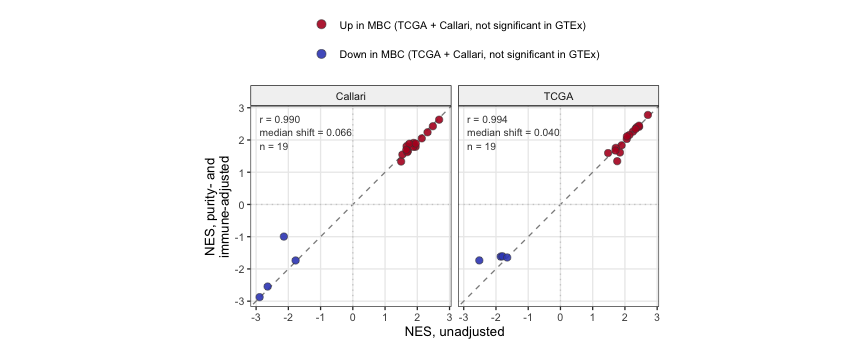

```r
rng <- range(c(nes_long$before, nes_long$after))

p_nes_all <- ggplot(nes_long, aes(before, after)) +
  geom_abline(linetype = 2, colour = "grey55") +
  geom_hline(yintercept = 0, linetype = 3, colour = "grey80") +
  geom_vline(xintercept = 0, linetype = 3, colour = "grey80") +
  geom_point(aes(fill = dir_lab), shape = 21, size = 2.4,
             colour = "grey25", stroke = .3, alpha = .9) +
  geom_text(data = stats, aes(x = rng[1], y = rng[2], label = txt),
            inherit.aes = FALSE, hjust = 0, vjust = 1, size = 2.7,
            colour = "grey25", lineheight = 1.1) +
  facet_wrap(~ cohort) +
  coord_equal(xlim = rng, ylim = rng) +
  scale_fill_manual(values = c(
      "Up in MBC (TCGA + Callari, not significant in GTEx)"   = "#B40426",
      "Down in MBC (TCGA + Callari, not significant in GTEx)" = "#3B4CC0"), name = NULL) +
  guides(fill = guide_legend(nrow = 2, override.aes = list(size = 3))) +
  labs(x = "NES, unadjusted", y = "NES, purity- and\nimmune-adjusted") +
  theme_bw(base_size = 10) +
  theme(panel.grid.minor = element_blank(),
        strip.background = element_rect(fill = "grey95", colour = "black"),
        legend.position = "top",
        legend.text = element_text(size = 8),
        plot.caption = element_text(hjust = 0, size = 7.5, colour = "grey40"))
p_nes_all
```

```r
ggsave(file.path(out_dir, "NES_adjusted_vs_unadjusted_all.pdf"), p_nes_all,
       width = 9, height = 3.6)
```

### 9b. Callari, by significance after adjustment

Significance is assessed in Callari, the better-balanced cohort (see section 8). Modules retaining FDR < 0.05 after adjustment are coloured by direction and labelled; those that no longer reach significance are grey. A grey point far from the diagonal indicates a module whose enrichment is explained by purity or immune infiltration.

```r
d <- nes_long[cohort == "Callari"]
d[, sig_after := !is.na(p_after) & p_after < 0.05]
d[, cls := fcase(
  sig_after & direction == "up_in_male",   "Up in MBC, retained after adjustment",
  sig_after & direction == "down_in_male", "Down in MBC, retained after adjustment",
  default = "Lost after adjustment (FDR > 0.05)")]
d[, cls := factor(cls, c("Up in MBC, retained after adjustment",
                         "Down in MBC, retained after adjustment",
                         "Lost after adjustment (FDR > 0.05)"))]
d[, .N, by = cls]
```

```
##                                       cls     N
##                                    <fctr> <int>
## 1: Down in MBC, retained after adjustment     3
## 2:     Lost after adjustment (FDR > 0.05)     3
## 3:   Up in MBC, retained after adjustment    13
```

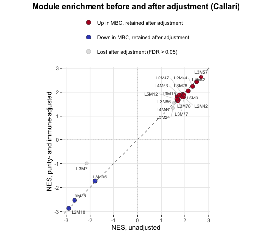

```r
p_nes_call <- ggplot(d, aes(before, after)) +
  geom_abline(linetype = 2, colour = "grey55") +
  geom_hline(yintercept = 0, linetype = 3, colour = "grey80") +
  geom_vline(xintercept = 0, linetype = 3, colour = "grey80") +
  ## grey first so highlighted points sit on top
  geom_point(data = d[cls == "Lost after adjustment (FDR > 0.05)"],
             aes(fill = cls), shape = 21, size = 2.2,
             colour = "grey60", stroke = .25, alpha = .75) +
  geom_point(data = d[cls != "Lost after adjustment (FDR > 0.05)"],
             aes(fill = cls), shape = 21, size = 2.8,
             colour = "grey20", stroke = .35) +
  geom_text_repel(aes(label = pathway), size = 2.4, colour = "grey25",
                  segment.size = .2, segment.colour = "grey70",
                  max.overlaps = 40, min.segment.length = .2,
                  show.legend = FALSE) +
  coord_equal(xlim = rng, ylim = rng) +
  scale_fill_manual(values = c(
      "Up in MBC, retained after adjustment"   = "#B40426",
      "Down in MBC, retained after adjustment" = "#3B4CC0",
      "Lost after adjustment (FDR > 0.05)"     = "grey85"),
    drop = FALSE, name = NULL) +
  guides(fill = guide_legend(nrow = 3, override.aes = list(size = 3))) +
  labs(x = "NES, unadjusted", y = "NES, purity- and immune-adjusted",
       title = "Module enrichment before and after adjustment (Callari)") +
  theme_bw(base_size = 10) +
  theme(panel.grid.minor = element_blank(),
        legend.position = "top",
        legend.text = element_text(size = 8),
        plot.title = element_text(hjust = .5, face = "bold"),
        plot.subtitle = element_text(hjust = .5, size = 9, colour = "grey35"),
        plot.caption = element_text(hjust = 0, size = 7.5, colour = "grey40"))
p_nes_call
```

```r
ggsave(file.path(out_dir, "NES_adjusted_vs_unadjusted_Callari.pdf"), p_nes_call,
       width = 5.5, height = 5)
```

## 10. Write outputs

```r
fwrite(tcga_meta, file.path(out_dir, "Purity_Immune_TCGA.csv"))
fwrite(call_meta, file.path(out_dir, "Purity_Immune_Callari.csv"))
fwrite(gtex_meta, file.path(out_dir, "Purity_Immune_GTEx.csv"))
fwrite(by_sex,    file.path(out_dir, "Purity_Immune_by_sex.csv"))

fwrite(gsea, file.path(out_dir, "module_gsea_adjusted_vs_unadjusted.csv"))
fwrite(w,    file.path(out_dir, "tumor_associated_modules_after_adjustment.csv"))
for (nm in names(DE))
  fwrite(DE[[nm]], file.path(out_dir, paste0("DE_", nm, ".csv")))

list.files(out_dir)
```

```
##  [1] "DE_Callari_adjusted.csv"
##  [2] "DE_Callari_unadjusted.csv"
##  [3] "DE_TCGA_adjusted.csv"
##  [4] "DE_TCGA_unadjusted.csv"
##  [5] "module_gsea_adjusted_vs_unadjusted.csv"
##  [6] "NES_adjusted_vs_unadjusted_all.pdf"
##  [7] "NES_adjusted_vs_unadjusted_Callari.pdf"
##  [8] "Purity_Immune_by_sex.csv"
##  [9] "purity_immune_by_sex.pdf"
## [10] "Purity_Immune_Callari.csv"
## [11] "Purity_Immune_GTEx.csv"
## [12] "Purity_Immune_TCGA.csv"
## [13] "tumor_associated_modules_after_adjustment.csv"
```